# Data Challenge 3 | Mario Saraiva (mhs2195)

Mario Saraiva (mhs2195)

4/16/2018

GR5069 - TOPICS IN APPLIED DATA SCIENCE FOR SOCIAL SCIENTISTS - Spring 2018

April 16, 2018

### Guidelines

Formulate two (2) conditional hypotheses that you seek to investigate with the data. 1. ( ) One of your hypotheses should condition on two variables (as the example on the slides) [50 pts], and

2. ( ) The other should condition on three variables. [50 pts]
3. ( ) formulate each one of your hypotheses explicitly in substantive terms (as opposed to statistical terms) using 2-3 lines at most
4. ( ) show exactly how each one of your hypotheses translates into the marginal effect that you will seek to estimate from the data
5. ( ) show the output from your analysis in a consumable form
6. ( ) show all your computations to estimate the corresponding marginal effect and
7. ( ) also show its standard error
8. ( ) be explicit in your assumptions
9. ( ) be explicit in the limitations of your inferences

phrase your finding for each question in two ways:

10. ( ) one sentence that summarizes your insight
11. ( ) one paragraph that reflects all nuance in your insight
12. ( ) make sure to also include your code

## Goal

**Hypothesis 1**

Given a municipality with an **acceptable level of access to Health Services** (that is at least 50% of residents have access to health services) and the **the numer of dead of municipal police officers** in the violent event, what is the marginal effect on the number of civilians dead?

**Note**: *This project will build upon the inferential analysis from Data Challenge #2.*

```r
#Lasso regression is run on perfect_lethality against all  numeric variables in our dataset:

# __Interpreting the Lasso Graph:__
#
# The colored line represents the value taken by a different coefficient in model 1. Lambda is the weight given to the regularization term (the L1 norm), so as lambda approaches zero, the loss function of your model approaches the OLS loss function. As lambda becomes larger, the regularization term has a greater effect and you will see fewer variables in your model. Our ideal lambda is the one that minimizes the residuals. In this case, a log of lambda of approximately -5 seems to be appropriate, as seen in the subsequent graph with MSE.

#Remove variables not suited for Lasso:
# [5] "state"
# [6] "state_abbr"
# [8] "municipality"
# [45] "source"
# [46] "organized_crime_lethality"
# [47] "army_lethality"
# [48] "navy_lethality"
# [49] "federal_police_lethality"
# [54] "organized_crime_NewIndex"
# [55] "army_NewIndex"
# [56] "navy_NewIndex"
# [57] "federal_police_NewIndex"
# [59] "category"
# [60] "global_id"
# [64] "Level.Social.Lag.2005"


### We first set up x and y
slim.dta.pov <- dta.pov[,-c(1,2,5,6,8,45,46,47,48,49,54,55,56,57,59,60,62,64)]

slim.dta.pov <- na.omit(slim.dta.pov)

set.seed(12345) # = Seed for replication

x <- model.matrix(perfect_lethality ~ ., data = slim.dta.pov)[,-46]
y <- slim.dta.pov$perfect_lethality

### We then fit a Lasso regression model (alpha = 1)
fit.lasso <- glmnet(x, y, alpha = 1, family = "gaussian")
#plot(fit.lasso, xvar = "lambda", label = TRUE)

### Now we cross-validate
cv.lasso <- cv.glmnet(x, y)
#plot(cv.lasso)
#
#Cross-Validation plot suggests that the model works best when it has approximately 5 predictors. We can use cross-validation to extract coefficients that collectively minimize mean squared error.
```

### Hypothesis 1

```r
dta.pov$Access.to.Health <- as.factor(cut(dta.pov$Access.Health.Services.pct, 2, labels = c("Poor", "Acceptable")))


### Regression with all variables
model.1 <- lm(civilian_dead ~  Access.to.Health*dta.pov$municipal_police_dead +  detained  + total_people_wounded + military_wounded + navy_wounded + small_arms_seized + army + ministerial_police + municipal_police + navy + state_police + Vulnerables.SocialCare.Pct.2010 + Access.Health.Services.pct, family = "binomial", data = dta.pov)

summary(model.1)
```

```
##
## Call:
## lm(formula = civilian_dead ~ Access.to.Health * dta.pov$municipal_police_dead +
##     detained + total_people_wounded + military_wounded + navy_wounded +
##     small_arms_seized + army + ministerial_police + municipal_police +
##     navy + state_police + Vulnerables.SocialCare.Pct.2010 + Access.Health.Services.pct,
##     data = dta.pov, family = "binomial")
##
## Residuals:
##    Min     1Q Median     3Q    Max
## -1.981 -0.127 -0.066 -0.018 51.395
##
## Coefficients:
##                                                            Estimate
## (Intercept)                                               0.0748069
## Access.to.HealthAcceptable                                0.0794660
## dta.pov$municipal_police_dead                             0.0635513
## detained                                                 -0.0121400
## total_people_wounded                                      0.0621952
## military_wounded                                         -0.0388632
## navy_wounded                                             -0.0716882
## small_arms_seized                                         0.0219619
## army                                                     -0.0823153
## ministerial_police                                       -0.0437669
## municipal_police                                         -0.1136549
## navy                                                     -0.0959241
## state_police                                             -0.0956273
## Vulnerables.SocialCare.Pct.2010                           0.0002645
## Access.Health.Services.pct                                0.0010248
## Access.to.HealthAcceptable:dta.pov$municipal_police_dead  0.1359452
##                                                          Std. Error
## (Intercept)                                               0.0684866
## Access.to.HealthAcceptable                                0.1093632
## dta.pov$municipal_police_dead                             0.0370939
## detained                                                  0.0060139
## total_people_wounded                                      0.0091864
## military_wounded                                          0.0252178
## navy_wounded                                              0.0620191
## small_arms_seized                                         0.0091814
## army                                                      0.0358023
```

[output cut: 32 more lines]

```
## small_arms_seized                                        *
## army                                                     *
## ministerial_police
## municipal_police                                         **
## navy
## state_police                                             .
## Vulnerables.SocialCare.Pct.2010
## Access.Health.Services.pct
## Access.to.HealthAcceptable:dta.pov$municipal_police_dead
## ---
## Signif. codes:  0 '***' 0.001 '**' 0.01 '*' 0.05 '.' 0.1 ' ' 1
##
## Residual standard error: 0.9156 on 4318 degrees of freedom
## Multiple R-squared:  0.01732,    Adjusted R-squared:  0.01391
## F-statistic: 5.074 on 15 and 4318 DF,  p-value: 4.482e-10
```

Results:

1. Given a municipality with an **acceptable level of access to Health Services** and the **the numer of dead of municipal police officers** in the violent event, the coefficient of the interaction was 0.1359452. The result was not statistically significant nor was it substantive. But the result is not yet the desired marinal effect. The marinal effect is calculated by

$$\beta_{Municipal Police Dead} + \beta_{Municipal Police * Access to Health Services} \\
0.0635513 + 0.1359452 = 0.1994965$$
So for every violent event in a municipality with an acceptable access to health services, given the number of municipal police officers dead, the marginal effect on total number of civilians dead is 0.1994. Then for every 5 municipal police officers dead in these municipalities 1 civilian is dead.

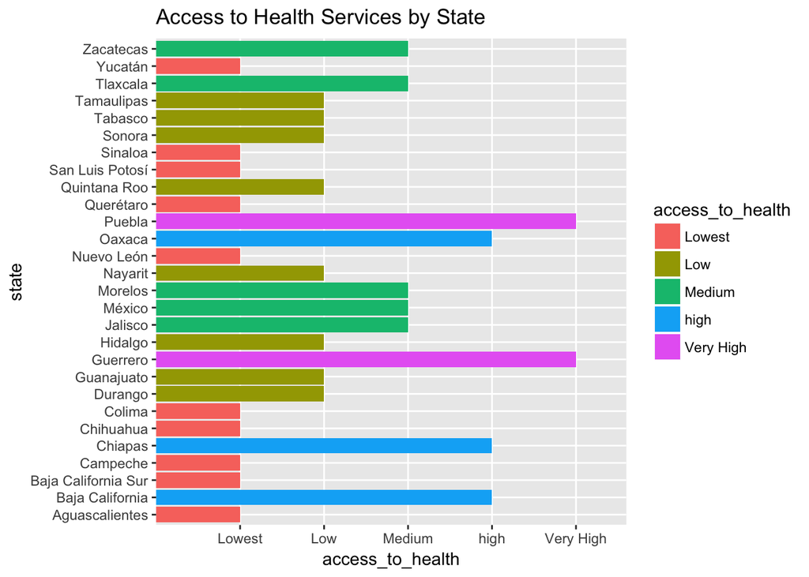

```r
dta2.pov <- dta.pov %>%
  group_by(state) %>%
  summarise(avg. = mean(dta.pov$federal_police_dead), avg.health = mean(Access.Health.Services.pct))

dta2.pov$access_to_health <- cut(dta2.pov$avg.health, 5, labels = c("Lowest", "Low", "Medium","high", "Very High"))

#Order values in ascending order.
# dta2.pov <- dta2.pov[order(dta2.pov$avg.health), ]
# dta2.pov$access_to_health <- factor(dta2.pov$access_to_health, levels=unique(as.character(dta2.pov$access_to_health)) )

ggplot(dta2.pov) + geom_col(aes(state, access_to_health, fill = access_to_health)) +
  coord_flip() + ggtitle("Access to Health Services by State")
```

```r
dta2.pov$avg2 <- cut(dta2.pov$avg., 4, c("Lowest", "Low", "Medium","high"))

#pander(table(dta2.pov$access_to_health, dta2.pov$avg2))
```

### Hypothesis 2

```r
### Regression with all variables
model.2 <- lm(civilian_dead ~  Access.to.Health*dta.pov$municipal_police_dead*long_guns_seized +  detained  + total_people_wounded + military_wounded + navy_wounded + small_arms_seized + army + ministerial_police + municipal_police + navy + state_police + Vulnerables.SocialCare.Pct.2010 + Access.Health.Services.pct, family = "binomial", data = dta.pov)
summary(model.2)
```

```
##
## Call:
## lm(formula = civilian_dead ~ Access.to.Health * dta.pov$municipal_police_dead *
##     long_guns_seized + detained + total_people_wounded + military_wounded +
##     navy_wounded + small_arms_seized + army + ministerial_police +
##     municipal_police + navy + state_police + Vulnerables.SocialCare.Pct.2010 +
##     Access.Health.Services.pct, data = dta.pov, family = "binomial")
##
## Residuals:
##    Min     1Q Median     3Q    Max
## -1.986 -0.127 -0.064 -0.017 51.396
##
## Coefficients:
##                                                                             Estimate
## (Intercept)                                                                0.0757750
## Access.to.HealthAcceptable                                                 0.1189475
## dta.pov$municipal_police_dead                                              0.0673517
## long_guns_seized                                                           0.0036668
## detained                                                                  -0.0127775
## total_people_wounded                                                       0.0624365
## military_wounded                                                          -0.0402437
## navy_wounded                                                              -0.0728881
## small_arms_seized                                                          0.0166918
## army                                                                      -0.0863193
## ministerial_police                                                        -0.0435941
## municipal_police                                                          -0.1121249
## navy                                                                      -0.1017425
## state_police                                                              -0.0949309
## Vulnerables.SocialCare.Pct.2010                                            0.0001755
## Access.Health.Services.pct                                                 0.0010167
## Access.to.HealthAcceptable:dta.pov$municipal_police_dead                   0.1346421
## Access.to.HealthAcceptable:long_guns_seized                               -0.0195337
## dta.pov$municipal_police_dead:long_guns_seized                            -0.0123317
## Access.to.HealthAcceptable:dta.pov$municipal_police_dead:long_guns_seized -0.2530620
##                                                                           Std. Error
## (Intercept)                                                                0.0685803
## Access.to.HealthAcceptable                                                 0.1178597
## dta.pov$municipal_police_dead                                              0.0375190
## long_guns_seized                                                           0.0034716
## detained                                                                   0.0061072
```

[output cut: 69 more lines]

```
## municipal_police                                                          **
## navy
## state_police                                                              .
## Vulnerables.SocialCare.Pct.2010
## Access.Health.Services.pct
## Access.to.HealthAcceptable:dta.pov$municipal_police_dead
## Access.to.HealthAcceptable:long_guns_seized
## dta.pov$municipal_police_dead:long_guns_seized
## Access.to.HealthAcceptable:dta.pov$municipal_police_dead:long_guns_seized
## ---
## Signif. codes:  0 '***' 0.001 '**' 0.01 '*' 0.05 '.' 0.1 ' ' 1
##
## Residual standard error: 0.9158 on 4314 degrees of freedom
## Multiple R-squared:  0.01787,    Adjusted R-squared:  0.01354
## F-statistic: 4.131 on 19 and 4314 DF,  p-value: 4.216e-09
```

Interpretation:

2.Given a municipality with an **acceptable level of access to Health Services**, the **the numer of dead of municipal police officers** and **the number of long-guns seized** in the violent event, the coefficient of the interaction was -0.2530620. The result was not statistically significant nor was it substantive. The actual marinal effect is calculated by

$$\beta_{Municipal Police Dead} + \beta_{long-guns seized} + \beta_{Municipal Police * Access to Health Services * long-guns seized} \\
0.0673517 + 0.0036668 + (-0.2530620) = -0.1820435$$

So for every violent event in a municipality with an acceptable access to health services, given the number of municipal police officers dead and the number of long-gun seized, the marginal effect on total number of civilians dead was negative (around -0.182).

### Discussion

**Limitations:**